# Data manipulation via tidyverse(focus on tidyr, stringr)

Mingli Liu

2022-07-27

# Outline

- Relational Data with dplyr
- Tidy Data with tidyr
- Strings with stringr

# 1. Relational Data with dplyr

- Keys: The variables used to connect each pair of tables are called keys. A key is a variable (or set of variables) that uniquely identifies an observation.
- Once you’ve identified the primary keys in your tables, it’s good practice to verify that they do indeed uniquely identify each observation.

```r
library(tidyverse)
library(nycflights13)
planes %>%
 count(tailnum) %>%
 filter(n > 1)
```

```
## # A tibble: 0 x 2
## # ... with 2 variables: tailnum <chr>, n <int>
```

# 1.1 Mutating Joins

### 1.1.1 Types of Joins

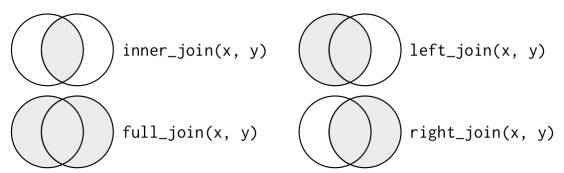

```r
flights2 <- flights %>%
 select(year:day, hour, origin, dest, tailnum, carrier)
flights2
```

```
## # A tibble: 336,776 x 8
##     year month   day  hour origin dest  tailnum carrier
##    <int> <int> <int> <dbl> <chr>  <chr> <chr>   <chr>
##  1  2013     1     1     5 EWR    IAH   N14228  UA
##  2  2013     1     1     5 LGA    IAH   N24211  UA
##  3  2013     1     1     5 JFK    MIA   N619AA  AA
##  4  2013     1     1     5 JFK    BQN   N804JB  B6
##  5  2013     1     1     6 LGA    ATL   N668DN  DL
##  6  2013     1     1     5 EWR    ORD   N39463  UA
##  7  2013     1     1     6 EWR    FLL   N516JB  B6
##  8  2013     1     1     6 LGA    IAD   N829AS  EV
##  9  2013     1     1     6 JFK    MCO   N593JB  B6
## 10  2013     1     1     6 LGA    ORD   N3ALAA  AA
## # ... with 336,766 more rows
```

```r
flights2 %>%
 select(-origin, -dest) %>%
 left_join(airlines, by = "carrier")
```

```
## # A tibble: 336,776 x 7
##     year month   day  hour tailnum carrier name
##    <int> <int> <int> <dbl> <chr>   <chr>   <chr>
##  1  2013     1     1     5 N14228  UA      United Air Lines Inc.
##  2  2013     1     1     5 N24211  UA      United Air Lines Inc.
##  3  2013     1     1     5 N619AA  AA      American Airlines Inc.
##  4  2013     1     1     5 N804JB  B6      JetBlue Airways
##  5  2013     1     1     6 N668DN  DL      Delta Air Lines Inc.
##  6  2013     1     1     5 N39463  UA      United Air Lines Inc.
##  7  2013     1     1     6 N516JB  B6      JetBlue Airways
##  8  2013     1     1     6 N829AS  EV      ExpressJet Airlines Inc.
##  9  2013     1     1     6 N593JB  B6      JetBlue Airways
## 10  2013     1     1     6 N3ALAA  AA      American Airlines Inc.
## # ... with 336,766 more rows
```

### 1.1.2 Defining the Key Columns

- The default, by = NULL, uses all variables that appear in both tables, the so-called natural join

```r
flights2 %>%
 left_join(weather)
```

```
## # A tibble: 336,776 x 18
##     year month   day  hour origin dest  tailnum carrier  temp  dewp humid wind_dir wind_speed wind_gust precip pressure visib
##    <int> <int> <int> <dbl> <chr>  <chr> <chr>   <chr>   <dbl> <dbl> <dbl>    <dbl>      <dbl>     <dbl>  <dbl>    <dbl> <dbl>
##  1  2013     1     1     5 EWR    IAH   N14228  UA       39.0  28.0  64.4      260       12.7      NA        0    1012.    10
##  2  2013     1     1     5 LGA    IAH   N24211  UA       39.9  25.0  54.8      250       15.0      21.9      0    1011.    10
##  3  2013     1     1     5 JFK    MIA   N619AA  AA       39.0  27.0  61.6      260       15.0      NA        0    1012.    10
##  4  2013     1     1     5 JFK    BQN   N804JB  B6       39.0  27.0  61.6      260       15.0      NA        0    1012.    10
##  5  2013     1     1     6 LGA    ATL   N668DN  DL       39.9  25.0  54.8      260       16.1      23.0      0    1012.    10
##  6  2013     1     1     5 EWR    ORD   N39463  UA       39.0  28.0  64.4      260       12.7      NA        0    1012.    10
##  7  2013     1     1     6 EWR    FLL   N516JB  B6       37.9  28.0  67.2      240       11.5      NA        0    1012.    10
##  8  2013     1     1     6 LGA    IAD   N829AS  EV       39.9  25.0  54.8      260       16.1      23.0      0    1012.    10
##  9  2013     1     1     6 JFK    MCO   N593JB  B6       37.9  27.0  64.3      260       13.8      NA        0    1013.    10
## 10  2013     1     1     6 LGA    ORD   N3ALAA  AA       39.9  25.0  54.8      260       16.1      23.0      0    1012.    10
## # ... with 336,766 more rows, and 1 more variable: time_hour <dttm>
```

- A character vector, by = “x”. This is like a natural join, but uses only some of the common variables.

```r
flights3 <- flights2 %>%
 left_join(planes, by = "tailnum")
```

- A named character vector: by = c(“a” = “b”). This will match variable a in table x to variable b in table y. The variables from x will be used in the output.

```r
flights2 %>%
 left_join(airports, c("dest" = "faa"))
```

```
## # A tibble: 336,776 x 15
##     year month   day  hour origin dest  tailnum carrier name                              lat   lon   alt    tz dst   tzone
##    <int> <int> <int> <dbl> <chr>  <chr> <chr>   <chr>   <chr>                           <dbl> <dbl> <dbl> <dbl> <chr> <chr>
##  1  2013     1     1     5 EWR    IAH   N14228  UA      George Bush Intercontinental     30.0 -95.3    97    -6 A     America/~
##  2  2013     1     1     5 LGA    IAH   N24211  UA      George Bush Intercontinental     30.0 -95.3    97    -6 A     America/~
##  3  2013     1     1     5 JFK    MIA   N619AA  AA      Miami Intl                       25.8 -80.3     8    -5 A     America/~
##  4  2013     1     1     5 JFK    BQN   N804JB  B6      <NA>                             NA    NA      NA    NA <NA>  <NA>
##  5  2013     1     1     6 LGA    ATL   N668DN  DL      Hartsfield Jackson Atlanta Intl  33.6 -84.4  1026    -5 A     America/~
##  6  2013     1     1     5 EWR    ORD   N39463  UA      Chicago Ohare Intl               42.0 -87.9   668    -6 A     America/~
##  7  2013     1     1     6 EWR    FLL   N516JB  B6      Fort Lauderdale Hollywood Intl   26.1 -80.2     9    -5 A     America/~
##  8  2013     1     1     6 LGA    IAD   N829AS  EV      Washington Dulles Intl           38.9 -77.5   313    -5 A     America/~
##  9  2013     1     1     6 JFK    MCO   N593JB  B6      Orlando Intl                     28.4 -81.3    96    -5 A     America/~
## 10  2013     1     1     6 LGA    ORD   N3ALAA  AA      Chicago Ohare Intl               42.0 -87.9   668    -6 A     America/~
## # ... with 336,766 more rows
```

### 1.1.3 Other Implementations

base::merge() can perform all four types of mutating join:

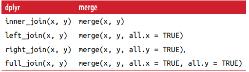

SQL is the inspiration for dplyr’s conventions, so the translation is straightforward:

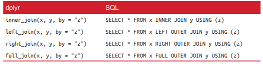

# 1.2 Filtering Joins

- Filtering joins match observations in the same way as mutating joins, but affect the observations, not the variables.
- • semi_join(x, y) keeps all observations in x that have a match in y.
- • anti_join(x, y) drops all observations in x that have a match in y.

```r
top_dest <- flights %>%
 count(dest, sort = TRUE) %>%
 head(10)
top_dest
```

```
## # A tibble: 10 x 2
##    dest      n
##    <chr> <int>
##  1 ORD   17283
##  2 ATL   17215
##  3 LAX   16174
##  4 BOS   15508
##  5 MCO   14082
##  6 CLT   14064
##  7 SFO   13331
##  8 FLL   12055
##  9 MIA   11728
## 10 DCA    9705
```

```r
flights %>%
 filter(dest %in% top_dest$dest)
```

```
## # A tibble: 141,145 x 19
##     year month   day dep_time sched_dep_time dep_delay arr_time sched_arr_time arr_delay carrier flight tailnum origin dest
##    <int> <int> <int>    <int>          <int>     <dbl>    <int>          <int>     <dbl> <chr>    <int> <chr>   <chr>  <chr>
##  1  2013     1     1      542            540         2      923            850        33 AA        1141 N619AA  JFK    MIA
##  2  2013     1     1      554            600        -6      812            837       -25 DL         461 N668DN  LGA    ATL
##  3  2013     1     1      554            558        -4      740            728        12 UA        1696 N39463  EWR    ORD
##  4  2013     1     1      555            600        -5      913            854        19 B6         507 N516JB  EWR    FLL
##  5  2013     1     1      557            600        -3      838            846        -8 B6          79 N593JB  JFK    MCO
##  6  2013     1     1      558            600        -2      753            745         8 AA         301 N3ALAA  LGA    ORD
##  7  2013     1     1      558            600        -2      924            917         7 UA         194 N29129  JFK    LAX
##  8  2013     1     1      558            600        -2      923            937       -14 UA        1124 N53441  EWR    SFO
##  9  2013     1     1      559            559         0      702            706        -4 B6        1806 N708JB  JFK    BOS
## 10  2013     1     1      600            600         0      851            858        -7 B6         371 N595JB  LGA    FLL
## # ... with 141,135 more rows, and 5 more variables: air_time <dbl>, distance <dbl>, hour <dbl>, minute <dbl>, time_hour <dttm>
```

- But it’s difficult to extend that approach to multiple variables.

```r
flights %>%
 semi_join(top_dest)
```

```
## # A tibble: 141,145 x 19
##     year month   day dep_time sched_dep_time dep_delay arr_time sched_arr_time arr_delay carrier flight tailnum origin dest
##    <int> <int> <int>    <int>          <int>     <dbl>    <int>          <int>     <dbl> <chr>    <int> <chr>   <chr>  <chr>
##  1  2013     1     1      542            540         2      923            850        33 AA        1141 N619AA  JFK    MIA
##  2  2013     1     1      554            600        -6      812            837       -25 DL         461 N668DN  LGA    ATL
##  3  2013     1     1      554            558        -4      740            728        12 UA        1696 N39463  EWR    ORD
##  4  2013     1     1      555            600        -5      913            854        19 B6         507 N516JB  EWR    FLL
##  5  2013     1     1      557            600        -3      838            846        -8 B6          79 N593JB  JFK    MCO
##  6  2013     1     1      558            600        -2      753            745         8 AA         301 N3ALAA  LGA    ORD
##  7  2013     1     1      558            600        -2      924            917         7 UA         194 N29129  JFK    LAX
##  8  2013     1     1      558            600        -2      923            937       -14 UA        1124 N53441  EWR    SFO
##  9  2013     1     1      559            559         0      702            706        -4 B6        1806 N708JB  JFK    BOS
## 10  2013     1     1      600            600         0      851            858        -7 B6         371 N595JB  LGA    FLL
## # ... with 141,135 more rows, and 5 more variables: air_time <dbl>, distance <dbl>, hour <dbl>, minute <dbl>, time_hour <dttm>
```

```r
flights %>%
 anti_join(planes, by = "tailnum") %>%
 count(tailnum, sort = TRUE)
```

```
## # A tibble: 722 x 2
##    tailnum     n
##    <chr>   <int>
##  1 <NA>     2512
##  2 N725MQ    575
##  3 N722MQ    513
##  4 N723MQ    507
##  5 N713MQ    483
##  6 N735MQ    396
##  7 N0EGMQ    371
##  8 N534MQ    364
##  9 N542MQ    363
## 10 N531MQ    349
## # ... with 712 more rows
```

# 1.3 Set Operations

- intersect(x, y)  
  Return only observations in both x and y.
- union(x, y)  
  Return unique observations in x and y.
- setdiff(x, y)  
  Return observations in x, but not in y.

```r
df1 <- tribble(
 ~x, ~y,
 1, 1,
 2, 1
)
df2 <- tribble(
 ~x, ~y,
 1, 1,
 1, 2
)
intersect(df1, df2)
```

```
## # A tibble: 1 x 2
##       x     y
##   <dbl> <dbl>
## 1     1     1
```

```r
union(df1, df2)
```

```
## # A tibble: 3 x 2
##       x     y
##   <dbl> <dbl>
## 1     1     1
## 2     2     1
## 3     1     2
```

```r
setdiff(df1, df2)
```

```
## # A tibble: 1 x 2
##       x     y
##   <dbl> <dbl>
## 1     2     1
```

# 2. Tidy Data with tidyr

### 2.1 Tidy Data

```r
library(tidyverse)
```

```r
table1
```

```
## # A tibble: 6 x 4
##   country      year  cases population
##   <chr>       <int>  <int>      <int>
## 1 Afghanistan  1999    745   19987071
## 2 Afghanistan  2000   2666   20595360
## 3 Brazil       1999  37737  172006362
## 4 Brazil       2000  80488  174504898
## 5 China        1999 212258 1272915272
## 6 China        2000 213766 1280428583
```

```r
table2
```

```
## # A tibble: 12 x 4
##    country      year type            count
##    <chr>       <int> <chr>           <int>
##  1 Afghanistan  1999 cases             745
##  2 Afghanistan  1999 population   19987071
##  3 Afghanistan  2000 cases            2666
##  4 Afghanistan  2000 population   20595360
##  5 Brazil       1999 cases           37737
##  6 Brazil       1999 population  172006362
##  7 Brazil       2000 cases           80488
##  8 Brazil       2000 population  174504898
##  9 China        1999 cases          212258
## 10 China        1999 population 1272915272
## 11 China        2000 cases          213766
## 12 China        2000 population 1280428583
```

```r
table3
```

```
## # A tibble: 6 x 3
##   country      year rate
## * <chr>       <int> <chr>
## 1 Afghanistan  1999 745/19987071
## 2 Afghanistan  2000 2666/20595360
## 3 Brazil       1999 37737/172006362
## 4 Brazil       2000 80488/174504898
## 5 China        1999 212258/1272915272
## 6 China        2000 213766/1280428583
```

```r
table4a
```

```
## # A tibble: 3 x 3
##   country     `1999` `2000`
## * <chr>        <int>  <int>
## 1 Afghanistan    745   2666
## 2 Brazil       37737  80488
## 3 China       212258 213766
```

```r
table4b
```

```
## # A tibble: 3 x 3
##   country         `1999`     `2000`
## * <chr>            <int>      <int>
## 1 Afghanistan   19987071   20595360
## 2 Brazil       172006362  174504898
## 3 China       1272915272 1280428583
```

- There are three interrelated rules which make a dataset tidy:
  1. Each variable must have its own column.
  2. Each observation must have its own row.
  3. Each value must have its own cell.

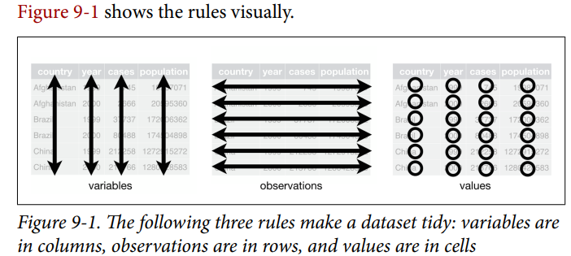

### 2.2 Pivoting: pivot_longer() and pivot_wider()

```r
tidy4a <- table4a %>%
  pivot_longer(c(`1999`, `2000`), names_to = "year", values_to = "cases")
tidy4b <- table4b %>%
  pivot_longer(c(`1999`, `2000`), names_to = "year", values_to = "population")
left_join(tidy4a, tidy4b)
```

```
## # A tibble: 6 x 4
##   country     year   cases population
##   <chr>       <chr>  <int>      <int>
## 1 Afghanistan 1999     745   19987071
## 2 Afghanistan 2000    2666   20595360
## 3 Brazil      1999   37737  172006362
## 4 Brazil      2000   80488  174504898
## 5 China       1999  212258 1272915272
## 6 China       2000  213766 1280428583
```

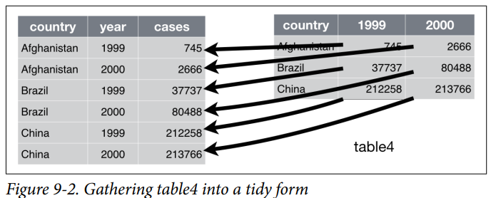

```r
table2 %>%
    pivot_wider(names_from = type, values_from = count)
```

```
## # A tibble: 6 x 4
##   country      year  cases population
##   <chr>       <int>  <int>      <int>
## 1 Afghanistan  1999    745   19987071
## 2 Afghanistan  2000   2666   20595360
## 3 Brazil       1999  37737  172006362
## 4 Brazil       2000  80488  174504898
## 5 China        1999 212258 1272915272
## 6 China        2000 213766 1280428583
```

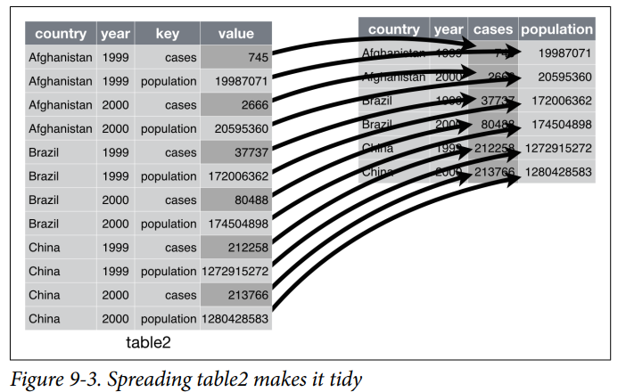

### 2.3 tidyr: gather() and spread()(Switching to pivot_longer and pivot_wider in new version)

```r
tidy4a <- table4a %>%
 gather(`1999`, `2000`, key = "year", value = "cases")
tidy4b <- table4b %>%
 gather(`1999`, `2000`, key = "year", value = "population")
left_join(tidy4a, tidy4b)
```

```
## # A tibble: 6 x 4
##   country     year   cases population
##   <chr>       <chr>  <int>      <int>
## 1 Afghanistan 1999     745   19987071
## 2 Brazil      1999   37737  172006362
## 3 China       1999  212258 1272915272
## 4 Afghanistan 2000    2666   20595360
## 5 Brazil      2000   80488  174504898
## 6 China       2000  213766 1280428583
```

```r
spread(table2, key = type, value = count)
```

```
## # A tibble: 6 x 4
##   country      year  cases population
##   <chr>       <int>  <int>      <int>
## 1 Afghanistan  1999    745   19987071
## 2 Afghanistan  2000   2666   20595360
## 3 Brazil       1999  37737  172006362
## 4 Brazil       2000  80488  174504898
## 5 China        1999 212258 1272915272
## 6 China        2000 213766 1280428583
```

### 2.4 Separate

```r
table3 %>%
 separate(rate, into = c("cases", "population"))
```

```
## # A tibble: 6 x 4
##   country      year cases  population
##   <chr>       <int> <chr>  <chr>
## 1 Afghanistan  1999 745    19987071
## 2 Afghanistan  2000 2666   20595360
## 3 Brazil       1999 37737  172006362
## 4 Brazil       2000 80488  174504898
## 5 China        1999 212258 1272915272
## 6 China        2000 213766 1280428583
```

- By default, separate() will split values wherever it sees a nonalphanumeric character (i.e., a character that isn’t a number or letter)

```r
table3 %>%
 separate(rate, into = c("cases", "population"), sep = "/")
```

```
## # A tibble: 6 x 4
##   country      year cases  population
##   <chr>       <int> <chr>  <chr>
## 1 Afghanistan  1999 745    19987071
## 2 Afghanistan  2000 2666   20595360
## 3 Brazil       1999 37737  172006362
## 4 Brazil       2000 80488  174504898
## 5 China        1999 212258 1272915272
## 6 China        2000 213766 1280428583
```

```r
table3 %>%
  separate(year, into = c("century", "year"), sep = 2)
```

```
## # A tibble: 6 x 4
##   country     century year  rate
##   <chr>       <chr>   <chr> <chr>
## 1 Afghanistan 19      99    745/19987071
## 2 Afghanistan 20      00    2666/20595360
## 3 Brazil      19      99    37737/172006362
## 4 Brazil      20      00    80488/174504898
## 5 China       19      99    212258/1272915272
## 6 China       20      00    213766/1280428583
```

### 2.5 Unite

```r
table5
```

```
## # A tibble: 6 x 4
##   country     century year  rate
## * <chr>       <chr>   <chr> <chr>
## 1 Afghanistan 19      99    745/19987071
## 2 Afghanistan 20      00    2666/20595360
## 3 Brazil      19      99    37737/172006362
## 4 Brazil      20      00    80488/174504898
## 5 China       19      99    212258/1272915272
## 6 China       20      00    213766/1280428583
```

```r
table5 %>%
 unite(new, century, year)
```

```
## # A tibble: 6 x 3
##   country     new   rate
##   <chr>       <chr> <chr>
## 1 Afghanistan 19_99 745/19987071
## 2 Afghanistan 20_00 2666/20595360
## 3 Brazil      19_99 37737/172006362
## 4 Brazil      20_00 80488/174504898
## 5 China       19_99 212258/1272915272
## 6 China       20_00 213766/1280428583
```

- The default will place an underscore (_) between the values from different columns.

```r
table5 %>%
 unite(new, century, year, sep = "")
```

```
## # A tibble: 6 x 3
##   country     new   rate
##   <chr>       <chr> <chr>
## 1 Afghanistan 1999  745/19987071
## 2 Afghanistan 2000  2666/20595360
## 3 Brazil      1999  37737/172006362
## 4 Brazil      2000  80488/174504898
## 5 China       1999  212258/1272915272
## 6 China       2000  213766/1280428583
```

### 2.6 Missing Values

- Explicitly, i.e., flagged with NA.
- Implicitly, i.e., simply not present in the data.

```r
stocks <- tibble(
 year = c(2015, 2015, 2015, 2015, 2016, 2016, 2016),
 qtr = c( 1, 2, 3, 4, 2, 3, 4),
 return = c(1.88, 0.59, 0.35, NA, 0.92, 0.17, 2.66)
)
stocks
```

```
## # A tibble: 7 x 3
##    year   qtr return
##   <dbl> <dbl>  <dbl>
## 1  2015     1   1.88
## 2  2015     2   0.59
## 3  2015     3   0.35
## 4  2015     4  NA
## 5  2016     2   0.92
## 6  2016     3   0.17
## 7  2016     4   2.66
```

```r
stocks %>%
  pivot_wider(names_from = year, values_from = return)
```

```
## # A tibble: 4 x 3
##     qtr `2015` `2016`
##   <dbl>  <dbl>  <dbl>
## 1     1   1.88  NA
## 2     2   0.59   0.92
## 3     3   0.35   0.17
## 4     4  NA      2.66
```

- set values_drop_na = TRUE in pivot_longer() to turn explicit missing values implicit

```r
stocks %>%
  pivot_wider(names_from = year, values_from = return) %>%
  pivot_longer(
    cols = c(`2015`, `2016`),
    names_to = "year",
    values_to = "return",
    values_drop_na = TRUE
  )
```

```
## # A tibble: 6 x 3
##     qtr year  return
##   <dbl> <chr>  <dbl>
## 1     1 2015    1.88
## 2     2 2015    0.59
## 3     2 2016    0.92
## 4     3 2015    0.35
## 5     3 2016    0.17
## 6     4 2016    2.66
```

-Another important tool for making missing values explicit in tidy data is complete(): - complete() takes a set of columns, and finds all unique combinations. It then ensures the original dataset contains all those values, filling in explicit NAs where necessary.

```r
stocks
```

```
## # A tibble: 7 x 3
##    year   qtr return
##   <dbl> <dbl>  <dbl>
## 1  2015     1   1.88
## 2  2015     2   0.59
## 3  2015     3   0.35
## 4  2015     4  NA
## 5  2016     2   0.92
## 6  2016     3   0.17
## 7  2016     4   2.66
```

```r
stocks %>%
  complete(year, qtr)
```

```
## # A tibble: 8 x 3
##    year   qtr return
##   <dbl> <dbl>  <dbl>
## 1  2015     1   1.88
## 2  2015     2   0.59
## 3  2015     3   0.35
## 4  2015     4  NA
## 5  2016     1  NA
## 6  2016     2   0.92
## 7  2016     3   0.17
## 8  2016     4   2.66
```

- Sometimes when a data source has primarily been used for data entry, missing values indicate that the previous value should be carried forward: fill()

```r
treatment <- tribble(
  ~ person,           ~ treatment, ~response,
  "Derrick Whitmore", 1,           7,
  NA,                 2,           10,
  NA,                 3,           9,
  "Katherine Burke",  1,           4
)
treatment %>%
  fill(person)
```

```
## # A tibble: 4 x 3
##   person           treatment response
##   <chr>                <dbl>    <dbl>
## 1 Derrick Whitmore         1        7
## 2 Derrick Whitmore         2       10
## 3 Derrick Whitmore         3        9
## 4 Katherine Burke          1        4
```

# 3. Strings with stringr

### 3.1 Prerequisites

```r
library(tidyverse)
```

# 3.2 String basics

```r
string1 <- "This is a string"
string2 <- 'If I want to include a "quote" inside a string, I use single quotes'

string1
```

```
## [1] "This is a string"
```

```r
string2
```

```
## [1] "If I want to include a \"quote\" inside a string, I use single quotes"
```

```r
writeLines(string2)
```

```
## If I want to include a "quote" inside a string, I use single quotes
```

- To include a literal single or double quote in a string you can use \ to “escape” it:

```r
double_quote <- "\"" # or '"'
single_quote <- '\'' # or "'"
```

- That means if you want to include a literal backslash, you’ll need to double it up: “\\”

```r
x <- c("\"", "\\")
x
```

```
## [1] "\"" "\\"
```

```r
writeLines(x)
```

```
## "
## \
```

- If you forget to close a quote, you’ll see +, the continuation character: >

> “This is a string without a closing quote  
> +  
> +  
> + HELP I’M STUCK
- If this happen to you, press Escape and try again!
- other special characters  
  “\n”, newline  
  “\t”, tab  
  “\u00b5”  
  the complete list by requesting help on “: ?‘“’, or ?”’”
- Multiple strings are often stored in a character vector, which you can create with c():

```r
c("one", "two", "three")
```

```
## [1] "one"   "two"   "three"
```

### 3.2.1 String length

- functions from stringr
- The common str_ prefix is particularly useful if you use RStudio

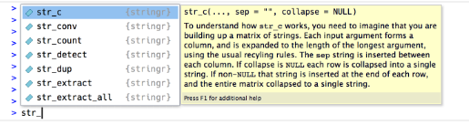

- example

```r
str_length(c("a", "R for data science", NA))
```

```
## [1]  1 18 NA
```

### 3.2.2 Combining strings

```r
str_c("x", "y")
```

```
## [1] "xy"
```

```r
str_c("x", "y", sep = ", ")
```

```
## [1] "x, y"
```

- Like most other functions in R, missing values are contagious. If you want them to print as “NA”, use str_replace_na():

```r
x <- c("abc", NA)
str_c("|-", x, "-|")
```

```
## [1] "|-abc-|" NA
```

```r
str_c("|-", str_replace_na(x), "-|")
```

```
## [1] "|-abc-|" "|-NA-|"
```

- Objects of length 0 are silently dropped. This is particularly useful in conjunction with if:

```r
name <- "Hadley"
time_of_day <- "morning"
birthday <- FALSE

str_c(
  "Good ", time_of_day, " ", name,
  if (birthday) " and HAPPY BIRTHDAY",
  "."
)
```

```
## [1] "Good morning Hadley."
```

- To collapse a vector of strings into a single string, use collapse:

```r
str_c(c("x", "y", "z"), collapse = ", ")
```

```
## [1] "x, y, z"
```

### 3.2.3 Subsetting strings

- str_sub() takes start and end arguments which give the (inclusive) position of the substring:

```r
x <- c("Apple", "Banana", "Pear")
str_sub(x, 1, 3)
```

```
## [1] "App" "Ban" "Pea"
```

```r
str_sub(x, -3, -1)
```

```
## [1] "ple" "ana" "ear"
```

- Note that str_sub() won’t fail if the string is too short: it will just return as much as possible:

```r
str_sub("a", 1, 5)
```

```
## [1] "a"
```

- You can also use the assignment form of str_sub() to modify strings:

```r
str_sub(x, 1, 1) <- str_to_lower(str_sub(x, 1, 1))
x
```

```
## [1] "apple"  "banana" "pear"
```

### 3.2.4 Locales

```r
# Turkish has two i's: with and without a dot, and it
# has a different rule for capitalising them:
str_to_upper(c("i", "ı"))
```

[output not shown]

```r
str_to_upper(c("i", "ı"), locale = "tr")
```

```
## [1] "İ" "ı"
```

- The base R order() and sort() functions sort strings using the current locale. If you want robust behaviour across different computers, you may want to use str_sort() and str_order() which take an additional locale argument:

```r
x <- c("apple", "eggplant", "banana")

str_sort(x, locale = "en")  # English
```

```
## [1] "apple"    "banana"   "eggplant"
```

```r
str_sort(x, locale = "haw") # Hawaiian
```

```
## [1] "apple"    "eggplant" "banana"
```

# 3.3 Matching patterns with regular expressions

- To learn regular expressions, we’ll use str_view() and str_view_all()

### 3.3.1 Basic matches

```r
x <- c("apple", "banana", "pear")
str_view(x, "an")
```

[interactive chart not shown]

- The next step up in complexity is ., which matches any character (except a newline):

```r
str_view(x, ".a.")
```

[interactive chart not shown]

- But if “.” matches any character, how do you match the character “.”?

```r
# To create the regular expression, we need \\
dot <- "\\."

# But the expression itself only contains one:
writeLines(dot)
```

```
## \.
```

```r
# And this tells R to look for an explicit .
str_view(c("abc", "a.c", "bef"), "a\\.c")
```

[interactive chart not shown]

- If \ is used as an escape character in regular expressions, how do you match a literal ?

```r
x <- "a\\b"
writeLines(x)
```

```
## a\b
```

```r
str_view(x, "\\\\")
```

[interactive chart not shown]

### 3.3.2 Anchors

- It’s often useful to anchor the regular expression so that it matches from the start or end of the string.

  ^ to match the start of the string.  
  $ to match the end of the string.

```r
x <- c("apple", "banana", "pear")
str_view(x, "^a")
```

[interactive chart not shown]

```r
str_view(x, "a$")
```

[interactive chart not shown]

- you begin with power (^), you end up with money ($).

```r
x <- c("apple pie", "apple", "apple cake")
str_view(x, "apple")
```

[interactive chart not shown]

```r
str_view(x, "^apple$")
```

[interactive chart not shown]

- You can also match the boundary between words with \b. \bsum\b

### 3.3.3 Character classes and alternatives

\d: matches any digit.  
\s: matches any whitespace (e.g. space, tab, newline).  
[abc]: matches a, b, or c.  
[^abc]: matches anything except a, b, or c.

Remember, to create a regular expression containing \d or \s, you’ll need to escape the \ for the string, so you’ll type “\\d” or “\\s”.

```r
# Look for a literal character that normally has special meaning in a regex
str_view(c("abc", "a.c", "a*c", "a c"), "a[.]c")
```

[interactive chart not shown]

```r
str_view(c("abc", "a.c", "a*c", "a c"), ".[*]c")
```

[interactive chart not shown]

- This works for most (but not all) regex metacharacters: $ . | ? * + ( ) [ {. Unfortunately, a few characters have special meaning even inside a character class and must be handled with backslash escapes: ] \ ^ and -
- use alternation to pick between one or more alternative patterns. For example,

  abc|d..f will match either ‘“abc”’, or “deaf”  
  abc|xyz matches abc or xyz not abcyz or abxyz

```r
str_view(c("grey", "gray"), "gr(e|a)y")
```

[interactive chart not shown]

### 3.3.4 Repetition

- The next step up in power involves controlling how many times a pattern matches:

  ?: 0 or 1  
  +: 1 or more  
  *: 0 or more

```r
x <- "1888 is the longest year in Roman numerals: MDCCCLXXXVIII"
str_view(x, "CC?")
```

[interactive chart not shown]

```r
str_view(x, "CC+")
```

[interactive chart not shown]

```r
str_view(x, 'C[LX]+')
```

[interactive chart not shown]

- Note that the precedence of these operators is high, that means most uses will need parentheses, like bana(na)+
- You can also specify the number of matches precisely:

  {n}: exactly n  
  {n,}: n or more  
  {,m}: at most  
  {n,m}: between n and m

```r
str_view(x, "C{2,3}")
```

[interactive chart not shown]

```r
str_view(x, 'C{2,3}?')
```

[interactive chart not shown]

### 3.3.5 Grouping and backreference

- Another Way by a capturing group with backreferences, like \1, \2 etc.

```r
str_view(fruit, "(..)\\1", match = TRUE)
```

[interactive chart not shown]

```r
fruittt <- c("banbnanbn", "banbnbnan", "papaya")
str_view(fruittt, "(..)(..)\\1\\2", match = TRUE)
```

[interactive chart not shown]

```r
str_view(fruittt, "(..)(..)\\2\\1", match = TRUE)
```

[interactive chart not shown]

# 3.4 Tools

### 3.4.1 Detect matches

- To determine if a character vector matches a pattern, use str_detect()

```r
x <- c("apple", "banana", "pear")
str_detect(x, "e")
```

```
## [1]  TRUE FALSE  TRUE
```

- Use sum() and mean()

```r
# How many common words start with t?
sum(str_detect(words, "^t"))
```

```
## [1] 65
```

```r
# What proportion of common words end with a vowel?
mean(str_detect(words, "[aeiou]$"))
```

```
## [1] 0.2765306
```

- complex logical conditions, For example, here are two ways to find all words that don’t contain any vowels

```r
# Find all words containing at least one vowel, and negate
no_vowels_1 <- !str_detect(words, "[aeiou]")
# Find all words consisting only of consonants (non-vowels)
no_vowels_2 <- str_detect(words, "^[^aeiou]+$")
identical(no_vowels_1, no_vowels_2)
```

```
## [1] TRUE
```

- A common use of str_detect() is to select the elements that match a pattern. You can do this with logical subsetting, or the convenient str_subset() wrapper:

```r
words[str_detect(words, "x$")]
```

```
## [1] "box" "sex" "six" "tax"
```

```r
str_subset(words, "x$")
```

```
## [1] "box" "sex" "six" "tax"
```

- Typically, however, your strings will be one column of a data frame, and you’ll want to use filter instead:

```r
df <- tibble(
  word = words,
  i = seq_along(word)
)
df %>%
  filter(str_detect(word, "x$"))
```

```
## # A tibble: 4 x 2
##   word      i
##   <chr> <int>
## 1 box     108
## 2 sex     747
## 3 six     772
## 4 tax     841
```

- A variation on str_detect() is str_count()

```r
x <- c("apple", "banana", "pear")
str_count(x, "a")
```

```
## [1] 1 3 1
```

- Note that matches never overlap.

```r
str_count("abababa", "aba")
```

```
## [1] 2
```

### 3.4.2 Extract matches

- To extract the actual text of a match, use str_extract()

```r
length(sentences)
```

```
## [1] 720
```

```r
head(sentences)
```

```
## [1] "The birch canoe slid on the smooth planks."  "Glue the sheet to the dark blue background."
## [3] "It's easy to tell the depth of a well."      "These days a chicken leg is a rare dish."
## [5] "Rice is often served in round bowls."        "The juice of lemons makes fine punch."
```

- Imagine we want to find all sentences that contain a colour.

```r
colours <- c("red", "orange", "yellow", "green", "blue", "purple")
colour_match <- str_c(colours, collapse = "|")
colour_match
```

```
## [1] "red|orange|yellow|green|blue|purple"
```

- Now we can select the sentences that contain a colour, and then extract the colour to figure out which one it is:

```r
has_colour <- str_subset(sentences, colour_match)
matches <- str_extract(has_colour, colour_match)
head(matches)
```

```
## [1] "blue" "blue" "red"  "red"  "red"  "blue"
```

- Note that str_extract() only extracts the first match. We can see that most easily by first selecting all the sentences that have more than 1 match

```r
more <- sentences[str_count(sentences, colour_match) > 1]
str_view_all(more, colour_match)
```

[interactive chart not shown]

```r
str_extract(more, colour_match)
```

```
## [1] "blue"   "green"  "orange"
```

- To get all matches, use str_extract_all()

```r
str_extract_all(more, colour_match)
```

```
## [[1]]
## [1] "blue" "red"
##
## [[2]]
## [1] "green" "red"
##
## [[3]]
## [1] "orange" "red"
```

- If you use simplify = TRUE, str_extract_all() will return a matrix with short matches expanded to the same length as the longest:

```r
str_extract_all(more, colour_match, simplify = TRUE)
```

```
##      [,1]     [,2]
## [1,] "blue"   "red"
## [2,] "green"  "red"
## [3,] "orange" "red"
```

### 3.4.3 Grouped matches

- use parentheses to extract parts of a complex match. For example, imagine we want to extract nouns from the sentences.

```r
noun <- "(a|the) ([^ ]+)"

has_noun <- sentences %>%
  str_subset(noun) %>%
  head(10)
has_noun %>%
  str_extract(noun)
```

```
##  [1] "the smooth" "the sheet"  "the depth"  "a chicken"  "the parked" "the sun"    "the huge"   "the ball"   "the woman"
## [10] "a helps"
```

- str_extract() gives us the complete match; str_match() gives each individual component.

```r
has_noun %>%
  str_match(noun)
```

```
##       [,1]         [,2]  [,3]
##  [1,] "the smooth" "the" "smooth"
##  [2,] "the sheet"  "the" "sheet"
##  [3,] "the depth"  "the" "depth"
##  [4,] "a chicken"  "a"   "chicken"
##  [5,] "the parked" "the" "parked"
##  [6,] "the sun"    "the" "sun"
##  [7,] "the huge"   "the" "huge"
##  [8,] "the ball"   "the" "ball"
##  [9,] "the woman"  "the" "woman"
## [10,] "a helps"    "a"   "helps"
```

- If your data is in a tibble, it’s often easier to use tidyr::extract().

```r
tibble(sentence = sentences) %>%
  tidyr::extract(
    sentence, c("article", "noun"), "(a|the) ([^ ]+)",
    remove = FALSE
  )
```

```
## # A tibble: 720 x 3
##    sentence                                    article noun
##    <chr>                                       <chr>   <chr>
##  1 The birch canoe slid on the smooth planks.  the     smooth
##  2 Glue the sheet to the dark blue background. the     sheet
##  3 It's easy to tell the depth of a well.      the     depth
##  4 These days a chicken leg is a rare dish.    a       chicken
##  5 Rice is often served in round bowls.        <NA>    <NA>
##  6 The juice of lemons makes fine punch.       <NA>    <NA>
##  7 The box was thrown beside the parked truck. the     parked
##  8 The hogs were fed chopped corn and garbage. <NA>    <NA>
##  9 Four hours of steady work faced us.         <NA>    <NA>
## 10 Large size in stockings is hard to sell.    <NA>    <NA>
## # ... with 710 more rows
```

### 3.4.4 Replacing matches

- str_replace() and str_replace_all() allow you to replace matches with new strings.

```r
x <- c("apple", "pear", "banana")
str_replace(x, "[aeiou]", "-")
```

```
## [1] "-pple"  "p-ar"   "b-nana"
```

```r
str_replace_all(x, "[aeiou]", "-")
```

```
## [1] "-ppl-"  "p--r"   "b-n-n-"
```

- With str_replace_all() you can perform multiple replacements by supplying a named vector:

```r
x <- c("1 house", "2 cars", "3 people")
str_replace_all(x, c("1" = "one", "2" = "two", "3" = "three"))
```

```
## [1] "one house"    "two cars"     "three people"
```

- Instead of replacing with a fixed string you can use backreferences to insert components of the match

```r
sentences %>%
  str_replace("([^ ]+) ([^ ]+) ([^ ]+)", "\\1 \\3 \\2") %>%
  head(5)
```

```
## [1] "The canoe birch slid on the smooth planks."  "Glue sheet the to the dark blue background."
## [3] "It's to easy tell the depth of a well."      "These a days chicken leg is a rare dish."
## [5] "Rice often is served in round bowls."
```

### 3.4.5 Splitting

- Use str_split() to split a string up into pieces.

```r
aa <- "a|b|c|d" %>%
  str_split("\\|")
aa
```

```
## [[1]]
## [1] "a" "b" "c" "d"
```

- Otherwise, like the other stringr functions that return a list, you can use simplify = TRUE to return a matrix

```r
sentences %>%
  head(5) %>%
  str_split(" ")
```

```
## [[1]]
## [1] "The"     "birch"   "canoe"   "slid"    "on"      "the"     "smooth"  "planks."
##
## [[2]]
## [1] "Glue"        "the"         "sheet"       "to"          "the"         "dark"        "blue"        "background."
##
## [[3]]
## [1] "It's"  "easy"  "to"    "tell"  "the"   "depth" "of"    "a"     "well."
##
## [[4]]
## [1] "These"   "days"    "a"       "chicken" "leg"     "is"      "a"       "rare"    "dish."
##
## [[5]]
## [1] "Rice"   "is"     "often"  "served" "in"     "round"  "bowls."
```

```r
sentences %>%
  head(5) %>%
  str_split(" ", simplify = TRUE)
```

```
##      [,1]    [,2]    [,3]    [,4]      [,5]  [,6]    [,7]     [,8]          [,9]
## [1,] "The"   "birch" "canoe" "slid"    "on"  "the"   "smooth" "planks."     ""
## [2,] "Glue"  "the"   "sheet" "to"      "the" "dark"  "blue"   "background." ""
## [3,] "It's"  "easy"  "to"    "tell"    "the" "depth" "of"     "a"           "well."
## [4,] "These" "days"  "a"     "chicken" "leg" "is"    "a"      "rare"        "dish."
## [5,] "Rice"  "is"    "often" "served"  "in"  "round" "bowls." ""            ""
```

- You can also request a maximum number of pieces:

```r
fields <- c("Name: Hadley: Hadley", "Country: NZ: Hadley", "Age: 35: Hadley")
fields %>% str_split(": ", n = 2, simplify = TRUE)
```

```
##      [,1]      [,2]
## [1,] "Name"    "Hadley: Hadley"
## [2,] "Country" "NZ: Hadley"
## [3,] "Age"     "35: Hadley"
```

- Instead of splitting up strings by patterns, you can also split up by character, line, sentence and word boundary()s:

```r
str_split(x, " ")[[1]]
```

```
## [1] "1"     "house"
```

```r
str_split(x, boundary("word"))[[1]]
```

```
## [1] "1"     "house"
```

### 3.4.6 Find matches

- str_locate() and str_locate_all() give you the starting and ending positions of each match.

# 3.5 Other types of pattern

- When you use a pattern that’s a string, it’s automatically wrapped into a call to regex():

# The regular call:  
str_view(fruit, “nana”)  
# Is shorthand for  
str_view(fruit, regex(“nana”))

- You can use the other arguments of regex() to control details of the match:
  1. ignore_case = TRUE allows characters to match either their uppercase or lowercase forms. This always uses the current locale.

```r
bananas <- c("banana", "Banana", "BANANA")
str_view(bananas, "banana")
```

[interactive chart not shown]

```r
str_view(bananas, regex("banana", ignore_case = TRUE))
```

[interactive chart not shown]

2. multiline = TRUE allows ^ and $ to match the start and end of each line rather than the start and end of the complete string.

```r
x <- "Line 1\nLine 2\nLine 3"
str_extract_all(x, "^Line")[[1]]
```

```
## [1] "Line"
```

```r
str_extract_all(x, regex("^Line", multiline = TRUE))[[1]]
```

```
## [1] "Line" "Line" "Line"
```

3. comments = TRUE allows you to use comments and white space to make complex regular expressions more understandable. Spaces are ignored, as is everything after #. To match a literal space, you’ll need to escape it: “\\”.

```r
phone <- regex("
  \\(?     # optional opening parens
  (\\d{3}) # area code
  [) -]?   # optional closing parens, space, or dash
  (\\d{3}) # another three numbers
  [ -]?    # optional space or dash
  (\\d{3}) # three more numbers
  ", comments = TRUE)

str_match("514-791-8141", phone)
```

```
##      [,1]          [,2]  [,3]  [,4]
## [1,] "514-791-814" "514" "791" "814"
```

4. dotall = TRUE allows . to match everything, including \n.
- There are three other functions you can use instead of regex():
  1. fixed(): matches exactly the specified sequence of bytes. It ignores all special regular expressions and operates at a very low level. This allows you to avoid complex escaping and can be much faster than regular expressions.  
     b.coll(): compare strings using standard collation rules.
  2. As you saw with str_split() you can use boundary() to match boundaries.

# 3.6 Other uses of regular expressions

- apropos() searches all objects available from the global environment. This is useful if you can’t quite remember the name of the function.

```r
apropos("replace")
```

```
##  [1] "%+replace%"                     ".rs.files.replaceBindings"      ".rs.registerReplaceHook"
##  [4] ".rs.replaceBinding"             ".rs.rpc.replace_comment_header" "replace"
##  [7] "replace_na"                     "setReplaceMethod"               "str_replace"
## [10] "str_replace_all"                "str_replace_na"                 "theme_replace"
```

- dir() lists all the files in a directory. For example, you can find all the R Markdown files in the current directory with:

```r
head(dir(pattern = "\\.Rmd$"))
```

```
## [1] "Advanced-R-graphics.Rmd"
## [2] "basic-R-graphics.Rmd"
## [3] "Basics-R.Rmd"
## [4] "Data-manipulation-via-tidyverse-focus-on-tidyr,-stringr-.Rmd"
## [5] "Data manipulation via tidyverse(focus on readr, dplyr).Rmd"
## [6] "Data manipulation via tidyverse(focus on tidyr, stringr).Rmd"
```